# T2 - Visualização de Dados

Maria Eduarda Mesquita Magalhães

2025-03-12

# 1 1 - FORMULAÇÃO E DOCUMENTAÇÃO DA IDEIA

## 1.1 a) ESCOLHA DA BASE DE DADOS:

Os dados analisados neste estudo referem-se aos homicídios no Brasil, abrangendo informações tanto sobre o panorama nacional quanto sobre as cinco regiões do país e seus estados individualmente.

Tenho um profundo interesse por essa temática, pois sou natural de uma cidade com altos índices de violência e passei minha infância testemunhando assassinatos perto da minha casa. A base de dados utilizada foi obtida a partir de um documento online do **Instituto de Pesquisa e Estratégia Econômica do Ceará (IPECE)**, que informa como fonte dos dados o **DATASUS, Mapa da Violência – 2014**.

A escolha dessa base se justifica pela relevância do tema e pelo interesse em compreender melhor a realidade da violência no estado do Ceará. Trata-se de uma base de dados de estrutura simples, cujas informações abrangem o período de **2001 a 2012**.

## 1.2 b) FORMULAÇÃO DA HIPÓTESE A SER VERIFICADA

O principal objetivo desta análise é comparar as estatísticas de homicídios no Brasil com as dos estados do nordeste, com ênfase no estado do Ceará. Além disso, buscamos identificar possíveis relações entre esses estados e as cinco macroregiões do país.Para guiar nossa investigação, formulamos as seguintes hipóteses:

1. **Qual macrorregião brasileira é a mais perigosa?**
2. **Quais são os estados mais perigosos do Brasil?**
3. **Qual estado teve a maior variação no número de homícidios ao longo do tempo? Esta variação foi positiva ou negativa?**

# 2 2 - ANÁLISE EXPLORATÓRIA DA BASE DE DADOS

## 2.1 a) VISÃO GERAL DOS DADOS

### 2.1.1 Carregando bibliotecas necessárias

```r
library(ggplot2)
library(readr)
library(readxl)
library(dplyr)
library(tidyverse)
library(forcats)
```

### 2.1.2 Criando variáveis as quais representam os arquivos csv do excel que contêm os

### 2.1.3 Dados necessários para plotar os gráficos a seguir

```r
dados_estados <- read_excel("dados_estados.csv")
dados_ce_mg <- read_excel("dados_ce_mg.csv")
dados_regiao <- read_excel("dados_regiao.csv")
dados_estados_regiao <- read_excel("dados_estados_regiao.csv")
resumo <- read_excel("medidas_resumo.csv")
```

### 2.1.4 Visualizações básicas para entender os dados:

```r
dados_ceara <- read_excel("dados_ce_mg.xlsx") %>%
  filter(regiao == "Ceará") %>%
  mutate(ano = as.integer(ano)) %>%
  arrange(ano)

dados_brasil <- read_excel("dados_ce_mg.xlsx") %>%
  filter(regiao == "BRASIL") %>%
  mutate(ano = as.integer(ano)) %>%
  arrange(ano)
```

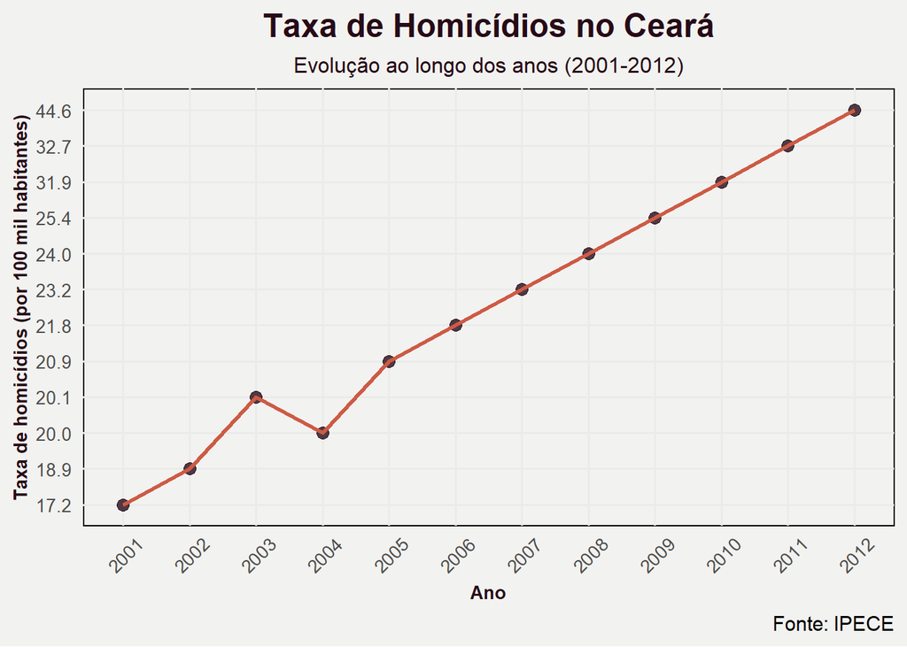

```r
ggplot(dados_ceara, aes(x = factor(ano), y = taxa, group = 1)) +
  geom_point(color = "#270B17", size = 3, alpha = 0.8) +
  geom_line(color = "#CD5B45", size = 1.2, linetype = "solid") +
  labs(title = "Taxa de Homicídios no Ceará",
       subtitle = "Evolução ao longo dos anos (2001-2012)",
       x = "Ano",
       y = "Taxa de homicídios (por 100 mil habitantes)",
       caption = "Fonte: IPECE",
       color = "Legenda") +

  theme_minimal(base_size = 14) +
  theme(
    plot.title = element_text(hjust = 0.5, size = 18, face = "bold", color = "#270B17"),
    plot.subtitle = element_text(hjust = 0.5, size = 12, color = "#270B17"),
    plot.background = element_rect(fill = "#F2F2F0", color = NA),
    panel.background = element_rect(fill = "#F2F2F0"),
    axis.text.x = element_text(angle = 45, vjust = 0.6, size = 10),
    axis.text.y = element_text(size = 10),
    axis.title.x = element_text(size = 10, face = "bold", color = "#270B17"),
    axis.title.y = element_text(size = 10, face = "bold", color = "#270B17"),
    axis.title = element_text(face = "bold")
  )
```

O eixo X representa os anos, de 2001 a 2012, com os valores discretos indicados como categorias. No eixo Y, temos a taxa de homicídios por 100 mil habitantes. A taxa é uma medida importante para compreender a violência no estado, já que a utiliza para comparar diferentes períodos de tempo independentemente da variação populacional.

A linha conectando os pontos é desenhada com uma cor laranja (#CD5B45), enquanto os pontos são destacados em um tom mais escuro de marrom (#270B17). Isso ajuda a chamar atenção para as mudanças ao longo do tempo, facilitando a percepção das flutuações na taxa de homicídios.

A estética do gráfico foi trabalhada para proporcionar uma leitura fácil e agradável. O tema minimalista utilizado na visualização contribui para que os dados sejam o centro das atenções, enquanto o fundo claro (#F2F2F0) cria um contraste suave com as cores dos elementos do gráfico. A legenda e os títulos também foram cuidadosamente ajustados, com fontes em negrito e alinhamento centralizado, o que facilita a compreensão e destaca a importância dos dados.

O gráfico é acompanhado de um subtítulo explicativo, destacando que se trata da evolução da taxa de homicídios ao longo de uma década (2001-2012), e a fonte dos dados é citada, garantindo a credibilidade da informação. A configuração da visualização foi pensada para ser acessível e atraente, facilitando a análise da série temporal e a identificação de padrões na evolução da violência no Ceará.

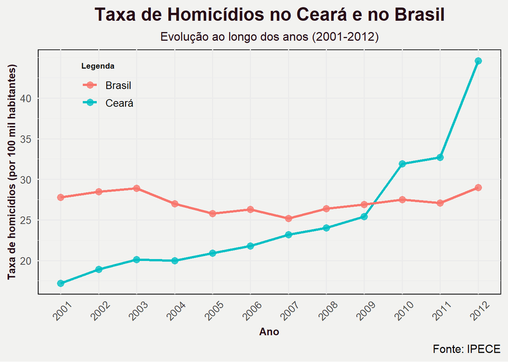

```r
ggplot() +
  geom_point(data = dados_ceara, aes(x = factor(ano), y = as.numeric(taxa), color = "Ceará"), size = 3, alpha = 0.8) +
  geom_line(data = dados_ceara, aes(x = factor(ano), y = as.numeric(taxa), group = 1, color = "Ceará"), size = 1.2, linetype = "solid") +
  geom_point(data = dados_brasil, aes(x = factor(ano), y = as.numeric(taxa), color = "Brasil"), size = 3, alpha = 0.8) +
  geom_line(data = dados_brasil, aes(x = factor(ano), y = as.numeric(taxa), group = 1, color = "Brasil"), size = 1.2, linetype = "solid") +
  labs(title = "Taxa de Homicídios no Ceará e no Brasil",
       subtitle = "Evolução ao longo dos anos (2001-2012)",
       x = "Ano",
       y = "Taxa de homicídios (por 100 mil habitantes)",
       caption = "Fonte: IPECE",
       color = "Legenda") +
  theme_minimal(base_size = 14) +
  theme(
    plot.title = element_text(hjust = 0.5, size = 18, face = "bold", color = "#270B17"),
    plot.subtitle = element_text(hjust = 0.5, size = 12, color = "#270B17"),
    plot.background = element_rect(fill = "#F2F2F0", color = NA),
    panel.background = element_rect(fill = "#F2F2F0"),
    axis.text.x = element_text(angle = 45, vjust = 0.6, size = 10),
    axis.text.y = element_text(size = 10),
    axis.title.x = element_text(size = 10, face = "bold", color = "#270B17"),
    axis.title.y = element_text(size = 10, face = "bold", color = "#270B17"),
    axis.title = element_text(face = "bold"),
    legend.position = c(0.15, 0.85),
    legend.title = element_text(size = 8, face = "bold"),
    legend.text = element_text(size = 10)
  ) +
  scale_y_continuous(breaks = seq(0, max(c(dados_ceara$taxa, dados_brasil$taxa)), by = 5))
```

Este gráfico compara a evolução da taxa de homicídios no estado do Ceará com a taxa de homicídios no Brasil entre os anos de 2001 e 2012. Utilizando pontos e linhas para representar ambas as séries temporais, o gráfico permite uma análise comparativa da violência no nível estadual e nacional ao longo do tempo.

O eixo X mostra os anos de 2001 a 2012, e o eixo Y representa a taxa de homicídios por 100 mil habitantes, com uma escala ajustada para facilitar a leitura, com intervalos de 5 unidades. Isso permite que a comparação entre as taxas de homicídios de ambos os conjuntos de dados seja feita de forma clara e intuitiva.

O gráfico foi projetado para ser visualmente acessível e informativo, permitindo uma comparação eficaz entre as taxas de homicídios do Ceará e do Brasil ao longo do período analisado. As mudanças nas taxas de homicídios de ambos os conjuntos de dados são evidenciadas, proporcionando uma visão clara das flutuações e tendências ao longo dos anos.

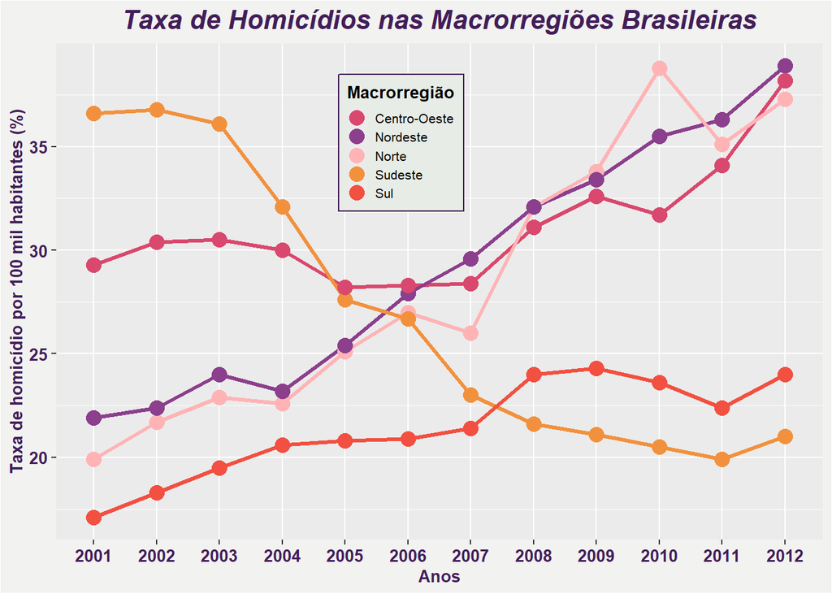

```r
dados_regiao$taxa <- as.numeric(dados_regiao$taxa)

ggplot(dados_regiao, aes(x = as.character(ano), y = taxa, color = regiao, group = regiao)) +
  geom_line(size = 1.2) +
  geom_point(size = 4) +
  labs(
    x = "Anos",
    y = "Taxa de homicídio por 100 mil habitantes (%)",
    title = "Taxa de Homicídios nas Macrorregiões Brasileiras",
    color = "Macrorregião"
  ) +
  scale_color_manual(values = c("#D9486E", "#8B3F8C", "#FFB3B5", "#F2913D", "#F25041")) +
  scale_x_discrete() +
  theme(
    plot.title = element_text(hjust = 0.5, size = 16, family = "Arial", face = "bold.italic", color = "#421E59"),
    plot.background = element_rect(fill = "#F2F2F0"),
    axis.title = element_text(hjust = 0.5, size = 10, family = "Arial", face = "bold", color = "#421E59"),
    axis.text.y = element_text(size = 10, family = "Arial", face = "bold", color = "#421E59"),
    axis.text.x = element_text(size = 10, family = "Arial", face = "bold", color = "#421E59"),
    legend.position = c(0.45, 0.8),
    legend.text = element_text(size = 8, family = "Arial"),
    legend.title = element_text(size = 10, face = "bold"),
    legend.background = element_rect(fill = "#E7ECE6", color = "#421E59", size = 0.4),
    legend.key.size = unit(0.6, "mm"),
      )
```

Este gráfico exibe a evolução da taxa de homicídios em diferentes macrorregiões brasileiras ao longo dos anos. Utilizando linhas e pontos, o gráfico permite a comparação das taxas de homicídios nas diversas regiões do Brasil, fornecendo uma visão clara das flutuações ao longo do tempo.

No eixo X, temos os anos, representados de forma discreta. O eixo Y, por sua vez, mostra a taxa de homicídios por 100 mil habitantes, permitindo medir a violência nas macrorregiões ao longo do período analisado. Cada linha no gráfico corresponde a uma macrorregião do Brasil, e as cores foram atribuídas de forma a distinguir facilmente as regiões, com uma paleta personalizada que inclui tons de rosa, roxo, laranja e vermelho (#D9486E, #8B3F8C, #FFB3B5, #F2913D, #F25041).

As linhas conectam os pontos representando a taxa de homicídios para cada ano, e os pontos são destacados para facilitar a visualização dos valores exatos. Isso ajuda a observar as variações na taxa de homicídios de forma mais precisa, além de evidenciar as tendências de cada macrorregião ao longo do tempo.

A estética do gráfico foi cuidadosamente projetada, com a escolha de cores vibrantes para as linhas e pontos, criando um contraste visual com o fundo claro (#F2F2F0). O título do gráfico e os rótulos dos eixos são apresentados de forma destacada e centralizada, com fontes em negrito e itálico, para dar ênfase às informações. A legenda, posicionada dentro do gráfico, facilita a identificação das diferentes macrorregiões, e a sua formatação com um fundo mais claro ajuda a destacar as informações sem prejudicar a legibilidade.

Além disso, a legenda foi ajustada para ocupar uma posição estratégica no gráfico, sem sobrecarregar a visualização das linhas e pontos. A fonte da legenda é simples e legível, com a utilização de um fundo leve para garantir um bom contraste com o restante do gráfico.

Esse gráfico foi projetado para oferecer uma análise visual clara e direta das taxas de homicídios nas macrorregiões brasileiras, permitindo identificar tendências e comparações ao longo do tempo de forma eficaz.

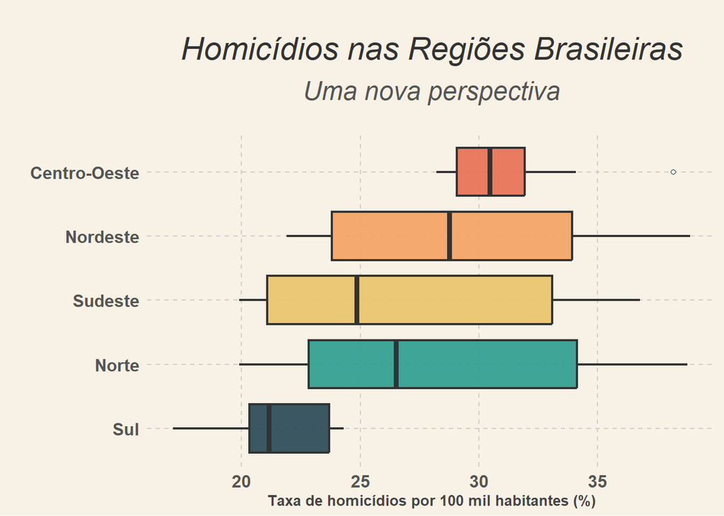

```r
dados_regiao$regiao <- fct_reorder(dados_regiao$regiao, dados_regiao$taxa, min)

ggplot(dados_regiao, aes(x = regiao, y = taxa, fill = regiao)) +
  geom_boxplot(size = 0.8, alpha = 0.9, outlier.shape = 21, outlier.fill = "white", outlier.color = "black") +
  scale_fill_manual(values = c("#264653", "#2A9D8F", "#E9C46A", "#F4A261", "#E76F51")) +
  labs(
    title = "Homicídios nas Regiões Brasileiras",
    subtitle = "Uma nova perspectiva",
    x = "",
    y = "Taxa de homicídios por 100 mil habitantes (%)"
  ) +
  theme_minimal(base_family = "Arial") +
  theme(
    plot.background = element_rect(fill = "#F8F1E5", color = NA),
    panel.background = element_rect(fill = "#F8F1E5", color = NA),
    plot.title = element_text(hjust = 0.5, size = 22, face = "italic", color = "#333333", margin = margin(20, 0, 10, 0)),
    plot.subtitle = element_text(hjust = 0.5, size = 18, face = "italic", color = "#555555", margin = margin(0, 0, 20, 0)),
    axis.title.y = element_text(size = 14, face = "bold", color = "#444444"),
    axis.title.x = element_text(size = 10, face = "bold", color = "#444444"),
    axis.text = element_text(size = 12, face = "bold", color = "#555555"),
    panel.grid.major = element_line(color = "gray80", linetype = "dashed"),
    panel.grid.minor = element_blank(),
    legend.position = "none"
  ) +
  coord_flip()
```

Este gráfico é um boxplot que compara a taxa de homicídios nas regiões brasileiras, oferecendo uma visão detalhada sobre a distribuição das taxas de homicídios em cada região. O gráfico foi projetado para mostrar a variação, a mediana e os outliers de cada região, proporcionando uma análise estatística visual clara.

O eixo Y representa a taxa de homicídios por 100 mil habitantes, enquanto o eixo X mostra as diferentes regiões brasileiras. As regiões estão ordenadas de acordo com a taxa de homicídios, da menor para a maior, com a ajuda da função `fct_reorder`, que ajusta a ordem das categorias no gráfico. O boxplot exibe a mediana (a linha dentro de cada caixa), o intervalo interquartil (a caixa), e os valores fora do intervalo (os outliers), que são mostrados como pontos individuais em branco, com bordas negras para destacar os valores extremos.

Cada região é colorida com uma paleta de cores personalizada que vai do verde ao laranja e vermelho (#264653, #2A9D8F, #E9C46A, #F4A261, #E76F51), facilitando a identificação visual das regiões e proporcionando um contraste agradável com o fundo claro (#F8F1E5). A ausência de legenda foi uma escolha deliberada para dar mais destaque às regiões, sem sobrecarregar o gráfico com informações desnecessárias.

O título do gráfico, “Homicídios nas Regiões Brasileiras”, é apresentado em itálico e está centralizado no topo do gráfico, com uma margem de espaçamento para destacá-lo. O subtítulo, “Uma nova perspectiva”, complementa o título e dá uma ideia de que este gráfico oferece uma nova maneira de olhar para os dados. Os rótulos dos eixos e os textos do gráfico são em negrito, tornando-os legíveis e bem destacados.

A estética geral do gráfico segue um estilo minimalista, com um fundo claro e suave, sem excessos, permitindo que o foco principal permaneça nas distribuições das taxas de homicídios. O uso da função `coord_flip` inverte os eixos X e Y, criando um gráfico horizontal que facilita a leitura das categorias, especialmente quando há várias regiões para comparar.

Este gráfico oferece uma visão clara das diferenças na taxa de homicídios entre as regiões brasileiras, ajudando a identificar quais regiões têm maior variação, quais são mais uniformes e onde os outliers se encontram. Ele é ideal para análises comparativas e para entender a distribuição da violência nas diferentes partes do Brasil.

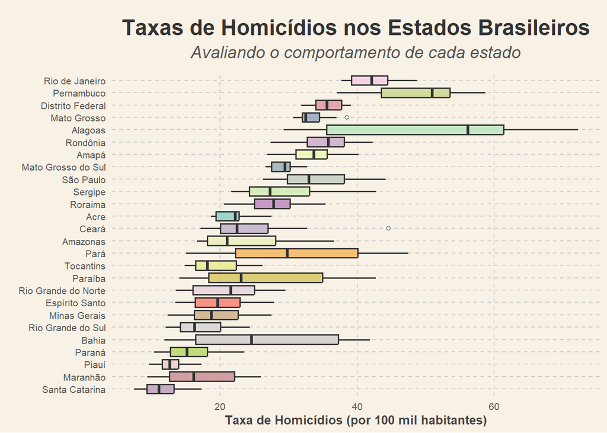

```r
dados_filtrados <- dados_estados %>%
  filter(regiao != "BRASIL")

paleta_27_cores <- colorRampPalette(RColorBrewer::brewer.pal(12, "Set3"))(27)
ggplot(dados_filtrados, aes(x = fct_reorder(regiao, taxa, .fun = min),
                            y = taxa, fill = regiao)) +
  geom_boxplot(size = 0.6, alpha = 0.85, outlier.shape = 21, outlier.color = "black", outlier.fill = "white") +
  scale_fill_manual(values = paleta_27_cores) +
  labs(
    title = "Taxas de Homicídios nos Estados Brasileiros",
    subtitle = "Avaliando o comportamento de cada estado",
    x = " ",
    y = "Taxa de Homicídios (por 100 mil habitantes)"
  ) +
  coord_flip() +
  guides(fill = FALSE) +
  theme_minimal(base_family = "Arial") +
  theme(
    plot.background = element_rect(fill = "#F8F1E5", color = NA),
    panel.background = element_rect(fill = "#F8F1E5", color = NA),
    plot.title = element_text(hjust = 0.5, size = 18, face = "bold", color = "#333333", margin = margin(10, 0, 5, 0)),
    plot.subtitle = element_text(hjust = 0.5, size = 14, face = "italic", color = "#555555", margin = margin(0, 0, 10, 0)),
    axis.title.x = element_text(size = 10, face = "bold", color = "#444444"),
    axis.title.y = element_text(size = 8, face = "bold", color = "#444444"),
    axis.text = element_text(size = 8, face = "plain", color = "#555555"),
    panel.grid.major = element_line(color = "gray80", linetype = "dashed"),
    panel.grid.minor = element_blank()
  )
```

As cores atribuídas a cada estado são originadas de uma paleta de 27 cores distintas, geradas pela função `colorRampPalette` e `RColorBrewer::brewer.pal`. Essas cores tornam o gráfico mais visualmente atraente e ajudam a diferenciar os estados entre si, facilitando a identificação de padrões ou anomalias. O gráfico também elimina a legenda, já que as cores estão diretamente associadas aos estados, tornando a visualização mais limpa e eficiente.

O título do gráfico, “Taxas de Homicídios nos Estados Brasileiros”, é centralizado e está em negrito, com um subtítulo em itálico que explica a finalidade do gráfico: “Avaliando o comportamento de cada estado”. Esses elementos textuais fornecem um contexto claro para a interpretação dos dados. O estilo do gráfico segue um padrão minimalista, com um fundo claro e fontes de cores sóbrias, garantindo legibilidade e um design agradável. A grade do painel é sutil, com linhas tracejadas, e o gráfico foi invertido utilizando a função `coord_flip()`, o que transforma o gráfico de vertical para horizontal. Esse ajuste melhora a legibilidade, especialmente em gráficos com muitas categorias no eixo X.